# 주제 선정 이유

우리의 생활과 밀접한 관련을 가지고 있는 것중 하나가 날씨이다. 이러한 날씨를 분석하고 예측해 우리에게 예보주는 것이 기상청의 역할이다.  
그러나 예전부터 최근까지도 이런한 기상청에 대한 비판은 끊이지 않는다. 실제로 일상생활을 하다보면 맑음이라고 예보된 날 비가 와서 급히 우산을 사거나, 비가 온다고 해서 우산을 챙겼지만 비가오지않아 짐이 늘어난 경험은 다들 한번쯤 해봤을 것이다.  
그렇기에 나는 이번 프로젝트에서 이렇게 일상생활과 밀접한 관계를 가지고 있는 날씨를 예보하는 기상청의 정확도를 측정해 보기위해 과거 기상청의 일기예보에서 예측한 강수확여부과 실제 강수횟수에 대한 데이터를 수집하고 비교해 기상청의 일기예보의 정확성을 판단해보려한다.

# 가설 정의

# 인터넷을 통한 데이터 획득

- 기상자료개방포털의 https://data.kma.go.kr/data/rmt/rmtList.do?code=400&pgmNo=570 링크에서 영통구의 각 동마다의 일별강수형태데이터를 csv파일로 획득했다.
- 기상자료개방포털의 https://data.kma.go.kr/data/rmt/rmtList.do?code=420&pgmNo=572 링크에서 영통구의 각 동마다의 일별강수형태의 단기예보데이터자료를 csv파일로 획득했다.
- 위 두가지 링크로 획득한 csv파일을 파이썬에서 csv모듈을 이용해 읽어오고 데이터 가공을 함

# 분석을 위한 데이터의 가공

```python
#실제 일별 강수형태관측 결과를 얻기위해 앞서 획득한 csv파일을 가공하여 정리

import csv
#csv파일을 불러오기위해 csv모듈을 import

location = ['maetan1','maetan2','maetan3','maetan4','woncheon','yeongtong1','yeongtong2','taejang','gwanggyo1','gwanggyo2']
year = ['2016','2017','2018']
rain = {}
#수집해야하는 데이터가 영통구의 각 동10개와 2016년부터 2018년 까지의 데이터이므로 이를 불러들이기 위해 location리스트와 year리스트를 만듦
#실제 강수형태 관측데이터를 저장할 수 있도록 rain이라는 빈 딕셔너리를 만듦
for i in location:
    for j in year:
        data_lst=[]
        information = open('{0}_{1}.csv'.format(i,j),'r')
        lines = csv.reader(information)
        #반복문을통해 실제 관측데이터 csv파일을 차례로 획득
        #csv파일에서 획득할 데이터를 지역과 년도에 나누어 임시로 저장할 공간이 필요하므로 data_lst라는 빈 리스트를 만듦
        k = 0
        #변수 k는 이후에 데이터 정보를 보기용이하게 만들 때 사용
        for line in lines:
        #csv파일 각 행을 하나씩 입력
            del line[1]
            #각 행의 두번째 열 정보인 시간정보는 이번 프로젝트에서 필요하지 않으므로 삭제
            if line[1] == '0' or line[0] == ' ':
                continue
            #데이터의 양이 너무 많으므로 맑음(0)으로 관측된 날의 날씨정보를 추출하지않음, 빈 데이터또한 추출하지않음
            else :
                data_lst.append(line)
            #관측결과 강수가 있었던 날의 정보를 data_lst안에 입력
            if 'Start' in line[1] or 'Start' in line[0]:
                k = k + 1
                data_lst.remove(line)
            else:
                line[0] = str(int(('{0}'.format(j))+str(k).zfill(2)+'01')+int(line[0])-1)
            #csv파일안 날짜의 일만 알려주던 첫번째 정보를 년.월.일모두 알려주도록 편집
            for test in data_lst:
                num_test = data_lst.count(test)
                if num_test>1:
                    for a in range(num_test-1):
                        data_lst.remove(test)
            data_lst.sort()
            #편집을 통해 데이터를 간략화,유연화하는 과정에서 발생한 동일한 데이터들을 제거, 남은 데이터를 정렬
            rain[i+'_'+j]=data_lst
            #처리된 데이터를 rain이라는 딕셔너리에 입력
        information.close()
        #csv파일을 닫음

rain_forecast = {}
#과거 강수형태 예보데이터를 저장할 수 있도록 rain_forecast라는 빈 딕셔너리를 만듦
for i in location:
    for j in year:
        data_lst=[]
        information = open('{0}_forecast_{1}.csv'.format(i,j),'r')
        lines = csv.reader(information)
        #반복문을통해 과거 예보데이터 csv파일을 차례로 획득
        #csv파일에서 획득할 데이터를 지역과 년도에 나누어 임시로 저장할 공간이 필요하므로 data_lst라는 빈 리스트를 만듦
        k = 0
        #변수 k는 이후에 데이터 정보를 보기용이하게 만들 때 사용
        for line in lines:
        #csv파일 각 행을 하나씩 입력
            del line[1]
            del line[1]
            #각 행의 두번째 열 정보인 시간정보와 세번째 열 정보인 예보기간 정보는 이번 프로젝트에서 필요하지 않으므로 삭제
            if line[1] == '0' or line[0] == ' ':
                continue
            #데이터의 양이 너무 많으므로 맑음(0)으로 예보된 날의 날씨정보를 추출하지않음, 빈 데이터또한 추출하지않음
            else :
                data_lst.append(line)
            #예보결과 강수가 있을 것이라던 날의 정보를 data_lst안에 입력
            if 'Start' in line[1] or 'Start' in line[0]:
                k = k + 1
                data_lst.remove(line)
            else:
                line[0] = str(int(('{0}'.format(j))+str(k).zfill(2)+'01')+int(line[0])-1)
            #csv파일안 날짜의 일만 알려주던 첫번째 정보를 년.월.일모두 알려주도록 편집

            for test in data_lst:
                num_test = data_lst.count(test)
                if num_test>1:
                    for a in range(num_test-1):
                        data_lst.remove(test)
            data_lst.sort()
            #편집을 통해 데이터를 간략화,유연화하는 과정에서 발생한 동일한 데이터들을 제거, 남은 데이터를 정렬
            rain_forecast[i+'_forecast_'+j]=data_lst
            #처리된 데이터를 rain이라는 딕셔너리에 입력
        information.close()
        #csv파일을 닫음
```

```python
#두 데이터 집합에서 두 번째 데이터인 강수형태데이터는 강수일수비교에 사용되지 않으므로 삭제함
for i in location:
    for j in year:
        for data in rain['{0}_{1}'.format(i,j)]:
            del data[1]
        for data_forecast in rain_forecast['{}_forecast_{}'.format(i,j)]:
            del data_forecast[1]
```

# 분석 결과 도출

```python
#각 예보 정확도를 지역별, 연도별로 나누어 분석해 보기위해 변수를 생성함
#여기서 매탄동, 영통동, 광교동은 지역을 세부적으로 나누지 않고 하나의 지역으로 합쳐서 분석

incorrect_maetan = []
incorrect_woncheon = []
incorrect_yeongtong = []
incorrect_taejang = []
incorrect_gwanggyo = []
#각 데이터를 저장하기 편하게 하기 위해 지역마다의 빈 리스트를 생성

for i in year:
    for j in ['maetan1','maetan2','maetan3','maetan4']:
        incorrect = 0
        #비교후 예보와 관측이 맞지않는 날짜의 수를 넣기 위헤 incorrect변수를 생성
        for data in rain['{0}_{1}'.format(j,i)]:
            if data not in rain_forecast['{0}_forecast_{1}'.format(j,i)]:
                incorrect += 1
            #실제 관측결과에선 강수가 있었지만 예보가 없던 날의 수만큼 변수에 더함
        for data_forecast in rain_forecast['{0}_forecast_{1}'.format(j,i)]:
            if data_forecast not in rain['{0}_{1}'.format(j,i)]:
                incorrect += 1
            #예보에선 강수가 있을것이라고 했지만 관측결과 강수가 없던 날의 수만큼 변수에 더함
        incorrect_maetan.append(incorrect)
        #각 지역과 연도마다의 예보가 부정확한 날짜의 수를 기록하여 빈 리스트에 저장

incorrect_maetan_2016 = 0
incorrect_maetan_2017 = 0
incorrect_maetan_2018 = 0
#부정확한 날의 수를 저장하기위해 변수를 생성

for i in range(len(incorrect_maetan)):
    if i < 4:
        incorrect_maetan_2016 += incorrect_maetan[i]
    elif 4 <= i < 8:
        incorrect_maetan_2017 += incorrect_maetan[i]
    else:
        incorrect_maetan_2018 += incorrect_maetan[i]
#빈 리스트에 1~4번째 값은 2016년도의 정보, 5~8번째 값은 2017년도의 정보, 9~12번째의 값은 2018년도의 정보이므로 이를 나누어서 변수에 저장

#아래로 동일한 작업을 지역별로 나누어서 실행
for i in year:
    j = 'woncheon'
    incorrect = 0
    for data in rain['{0}_{1}'.format(j,i)]:
        if data not in rain_forecast['{0}_forecast_{1}'.format(j,i)]:
            incorrect += 1
    for data_forecast in rain_forecast['{0}_forecast_{1}'.format(j,i)]:
        if data_forecast not in rain['{0}_{1}'.format(j,i)]:
            incorrect += 1
    incorrect_woncheon.append(incorrect)

incorrect_woncheon_2016 = incorrect_woncheon[0]
incorrect_woncheon_2017 = incorrect_woncheon[1]
incorrect_woncheon_2018 = incorrect_woncheon[2]

for i in year:
    for j in ['yeongtong1','yeongtong2']:
        incorrect = 0
        for data in rain['{0}_{1}'.format(j,i)]:
            if data not in rain_forecast['{0}_forecast_{1}'.format(j,i)]:
                incorrect += 1
        for data_forecast in rain_forecast['{0}_forecast_{1}'.format(j,i)]:
            if data_forecast not in rain['{0}_{1}'.format(j,i)]:
                incorrect += 1
        incorrect_yeongtong.append(incorrect)

incorrect_yeongtong_2016 = 0
incorrect_yeongtong_2017 = 0
incorrect_yeongtong_2018 = 0

for i in range(len(incorrect_yeongtong)):
    if i < 2:
        incorrect_yeongtong_2016 += incorrect_yeongtong[i]
    elif 2 <= i < 4:
        incorrect_yeongtong_2017 += incorrect_yeongtong[i]
    else:
        incorrect_yeongtong_2018 += incorrect_yeongtong[i]

for i in year:
    j = 'taejang'
    incorrect = 0
    for data in rain['{0}_{1}'.format(j,i)]:
        if data not in rain_forecast['{0}_forecast_{1}'.format(j,i)]:
            incorrect += 1
    for data_forecast in rain_forecast['{0}_forecast_{1}'.format(j,i)]:
        if data_forecast not in rain['{0}_{1}'.format(j,i)]:
            incorrect += 1
    incorrect_taejang.append(incorrect)

incorrect_taejang_2016 = incorrect_taejang[0]
incorrect_taejang_2017 = incorrect_taejang[1]
incorrect_taejang_2018 = incorrect_taejang[2]

for i in year:
    for j in ['gwanggyo1','gwanggyo2']:
        incorrect = 0
        for data in rain['{0}_{1}'.format(j,i)]:
            if data not in rain_forecast['{0}_forecast_{1}'.format(j,i)]:
                incorrect += 1
        for data_forecast in rain_forecast['{0}_forecast_{1}'.format(j,i)]:
            if data_forecast not in rain['{0}_{1}'.format(j,i)]:
                incorrect += 1
        incorrect_gwanggyo.append(incorrect)

incorrect_gwanggyo_2016 = 0
incorrect_gwanggyo_2017 = 0
incorrect_gwanggyo_2018 = 0

for i in range(len(incorrect_gwanggyo)):
    if i < 2:
        incorrect_gwanggyo_2016 += incorrect_gwanggyo[i]
    elif 2 <= i < 4:
        incorrect_gwanggyo_2017 += incorrect_gwanggyo[i]
    else:
        incorrect_gwanggyo_2018 += incorrect_gwanggyo[i]
```

```python
#연도에 따른 각 지역들의 예보 정확도정보를 저장하기위해 변수에 값을 대입하는 작업을 반복함
date_maetan_year = 365 * 4
date_woncheon_year = 365
date_yeongtong_year = 365 * 2
date_taejang_year = 365
date_gwanggyo_year = 365 * 2
#각 동의 집합마다 부속되어 있는 동의 수가 다르므로 위와같이 날짜의 수를 대입함
accuracy_maetan_2016 = (1 - incorrect_maetan_2016/date_maetan_year) * 100
accuracy_maetan_2017 = (1 - incorrect_maetan_2017/date_maetan_year) * 100
accuracy_maetan_2018 = (1 - incorrect_maetan_2018/date_maetan_year) * 100
accuracy_woncheon_2016 = (1 - incorrect_woncheon_2016/date_woncheon_year) * 100
accuracy_woncheon_2017 = (1 - incorrect_woncheon_2017/date_woncheon_year) * 100
accuracy_woncheon_2018 = (1 - incorrect_woncheon_2018/date_woncheon_year) * 100
accuracy_yeongtong_2016 = (1 - incorrect_yeongtong_2016/date_yeongtong_year) * 100
accuracy_yeongtong_2017 = (1 - incorrect_yeongtong_2017/date_yeongtong_year) * 100
accuracy_yeongtong_2018 = (1 - incorrect_yeongtong_2018/date_yeongtong_year) * 100
accuracy_taejang_2016 = (1 - incorrect_taejang_2016/date_taejang_year) * 100
accuracy_taejang_2017 = (1 - incorrect_taejang_2017/date_taejang_year) * 100
accuracy_taejang_2018 = (1 - incorrect_taejang_2018/date_taejang_year) * 100
accuracy_gwanggyo_2016 = (1 - incorrect_gwanggyo_2016/date_gwanggyo_year) * 100
accuracy_gwanggyo_2017 = (1 - incorrect_gwanggyo_2017/date_gwanggyo_year) * 100
accuracy_gwanggyo_2018 = (1 - incorrect_gwanggyo_2018/date_gwanggyo_year) * 100
#젠체 날짜의 수와 부정확한 예보의 수의 비율을 통해 예보 정확도를 계산함
#각 동마다 각 연도마다 나누어서 정확도를 계산하고 값을 대입함
```

```python
#지역별 3년간 총 예보정확도를 측정하고 변수에 대입함
date_maetan = 365 * 4 * 3
date_woncheon = 365 * 3
date_yeongtong = 365 * 2 * 3
date_taejang = 365 * 3
date_gwanggyo = 365 * 2 *3
#총 3년간 지역의 날짜의 수를 위와같이 대입함
incorrect_maetan =incorrect_maetan_2016 + incorrect_maetan_2017 +incorrect_maetan_2018
incorrect_woncheon =incorrect_woncheon_2016 + incorrect_woncheon_2017 + incorrect_woncheon_2018
incorrect_yeongtong = incorrect_yeongtong_2016 + incorrect_yeongtong_2017 + incorrect_yeongtong_2018
incorrect_taejang = incorrect_taejang_2016 + incorrect_taejang_2017 + incorrect_taejang_2018
incorrect_gwanggyo = incorrect_gwanggyo_2016 + incorrect_gwanggyo_2017 + incorrect_gwanggyo_2018
#총 3년간 각 지역의 부정확한 날의 수를 대입함
accuracy_maetan = (1 - incorrect_maetan/date_maetan) * 100
accuracy_woncheon = (1 - incorrect_woncheon/date_woncheon) * 100
accuracy_yeongtong = (1 - incorrect_yeongtong/date_yeongtong) * 100
accuracy_taejang = (1 - incorrect_taejang/date_taejang) * 100
accuracy_gwanggyo = (1 - incorrect_gwanggyo/date_gwanggyo) * 100
#정확도를 계산함
```

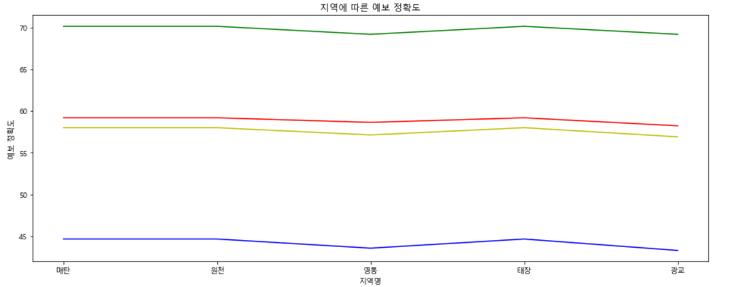

```python
#위 두 과정에서 얻은 연도별 각 지역의 예보정확도와 3년간의 예보정확도를 그래프로 표현함

import matplotlib.pyplot as plt
import matplotlib as mpl
#그래프를 그리기 위해 matplotlib 모듈을 import함
mpl.rc('font', family='Malgun Gothic')
#그래프에 한글폰트를 넣기 위한 작업을 함

plt.figure(figsize = (16,6)) #그래프의 사이즈를 결정
plt.plot(['매탄','원천','영통','태장','광교'],[accuracy_maetan_2016, accuracy_woncheon_2016, accuracy_yeongtong_2016, accuracy_taejang_2016,accuracy_gwanggyo_2016],'r')
plt.plot(['매탄','원천','영통','태장','광교'],[accuracy_maetan_2017, accuracy_woncheon_2017, accuracy_yeongtong_2017, accuracy_taejang_2017,accuracy_gwanggyo_2017],'b')
plt.plot(['매탄','원천','영통','태장','광교'],[accuracy_maetan_2018, accuracy_woncheon_2018, accuracy_yeongtong_2018, accuracy_taejang_2018,accuracy_gwanggyo_2018],'g')
plt.plot(['매탄','원천','영통','태장','광교'],[accuracy_maetan, accuracy_woncheon, accuracy_yeongtong, accuracy_taejang,accuracy_gwanggyo],'y')
#각 연도별 예보정확도와 총 예보정확도를 합한 4개의 데이터를 색을 다르게 하여 그래프로 표현
plt.xlabel('지역명')
plt.ylabel('예보 정확도')
plt.title('지역에 따른 예보 정확도')
#x축과 y축 제목에 어떠한 데이터가 들어갔는지에 대한 정보를 입력
plt.show()
#그래프를 보여줌
```

위 그래프에서 빨간색,파란색,초록색,노락색의 순서대로 2016년,2017년,2018년,3년간의 예보 정확도의 평균을 나태내었다.

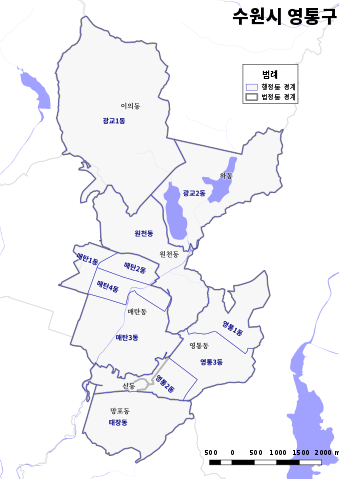

```python
#연도별 비교를 위해 값을 계산하고 변수를 설정한 뒤 입력함

date_year = 365 * 10
#각 연도별 10개의 동의 데이터가 들어갔으므로 총 일수를 위와 같이 계산함
incorrect_2016 = incorrect_maetan_2016 + incorrect_woncheon_2016 + incorrect_yeongtong_2016 + incorrect_taejang_2016 + incorrect_gwanggyo_2016
incorrect_2017 = incorrect_maetan_2017 + incorrect_woncheon_2017 + incorrect_yeongtong_2017 + incorrect_taejang_2017 + incorrect_gwanggyo_2017
incorrect_2018 = incorrect_maetan_2018 + incorrect_woncheon_2018 + incorrect_yeongtong_2018 + incorrect_taejang_2018 + incorrect_gwanggyo_2018
#연도별 부정확한 날의 수를 대입
accuracy_2016 = (1 - incorrect_2016/date_year) * 100
accuracy_2017 = (1 - incorrect_2017/date_year) * 100
accuracy_2018 = (1 - incorrect_2018/date_year) * 100
#각 연도별 정확도를 계산
```

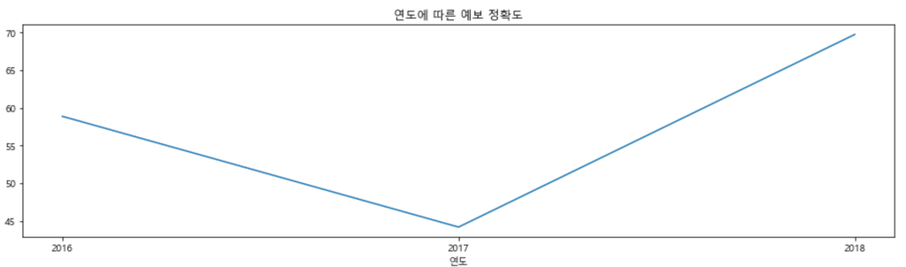

```python
#연도에따른 예보 정확도를 그래프로 나타내기 위해 위의 그래프 그리는 과정을 반복함
plt.figure(figsize = (16,4))
plt.plot(['2016','2017','2018'],[accuracy_2016, accuracy_2017, accuracy_2018])
plt.xlabel('연도')
plt.ylabel('예보 정확도')
plt.title('연도에 따른 예보 정확도')
plt.show()
```

```python
### 전체 지역의 3년간의 예보 정확도 측정 ###
incorrect = 0
full_date = 365 * 3 * 10
#전체 날짜수 정보를 넣기 위해 full_date변수를 생성(여기서 총 3년간 10개지역의 정보를 추출하였으므로 365*3*10의 값을 대입함)

for i in location:
    for j in year:
        for data in rain['{0}_{1}'.format(i,j)]:
            if data not in rain_forecast['{0}_forecast_{1}'.format(i,j)]:
                incorrect += 1
            #실제 관측결과에선 강수가 있었지만 예보가 없던 날의 수만큼 변수에 더함
        for data_forecast in rain_forecast['{0}_forecast_{1}'.format(i,j)]:
            if data_forecast not in rain['{0}_{1}'.format(i,j)]:
                incorrect += 1
            #예보에선 강수가 있을것이라고 했지만 관측결과 강수가 없던 날의 수만큼 변수에 더함

accuracy = (1 - incorrect/full_date) * 100
#젠체 날짜의 수와 부정확한 예보의 수의 비율을 통해 전체 예보 정확도를 계산함
print(accuracy)
```

[output not shown]

# 결론

# 참고문헌

-점프 투 파이썬 파일 읽고,쓰기 :https://wikidocs.net/26  
-동아리 교육자료  
-파이썬 코딩도장: https://dojang.io/